# Module 3 - GIS and Services Oriented Architectures

### Outline

- Geographic Information Systems
  - Data Types
  - Coordinate Systems
- Services Oriented Architectures
  - Historic Context
  - Current Model - Network Computing
  - Components
  - Interoperability Standards

## Geographic Information Systems

### Data Types - Vector

- Vector data represent phenomena that are associated with specific bounded locations, typically represented by:
  - Points
  - Lines
  - Polygons
- Vector data include:
  - The geometries that describe the area being referenced, and
  - Attributes associated with that area

For example, a census vector data product might include the geometries that define census tracts and attributes associated with each geometry: population, income, etc.

### Data Types - Raster

- Raster data are frequently used to represent values for phenomena that vary continuously across space (e.g. elevation, concentration of air pollutants, depth to ground water, etc. )
- These values are encoded over a regular grid of observation locations with a specified grid spacing - often referred to as the spatial resolution of the dataset (i.e. 10m resolution for a standard USGS Digital Elevation Model product)
- Often parts of data collections that are repeated (i.e. remote sensing data products)

### Accessing and Processing Raster and Vector Data

- Two geospatial libraries and their related utility programs provide information about and tools for modifying vector and raster data sets

**OGR**

vector data access and information

**GDAL**

raster data access and information

These libraries are the data access and processing foundation for a growing number of open source and commercial mapping systems

Information and documentation: [GDAL Home Page](http://gdal.org/) | [OGR Home Page](http://www.gdal.org/ogr/)

### Coordinate Systems/Projections

- To convert locations from a 3-dimensional oblate spherical coordinate system (such as is commonly used to represent the surface of the earth) to a 2-dimensional representation in a map, a coordinate transformation must be performed.
- There are a limitless number of potential coordinate transformations possible, and a large number have been named and defined that meet specific cartographic or other requirements

### EPSG Codes

- A catalog of numeric codes and associated coordinate transformation parameters is maintained by the International Association of Oil & Gas Producers (OGP) - the successor scientific organization to the European Petroleum Survey Group (EPSG)
- These numeric codes are used by many desktop and online mapping systems to document and represent the coordinate systems of available data and services
- Links to an online version of the registry and downloadable databases of the registry are available from: http://www.epsg.org/Geodetic.html.

### Projection Parameters

The parameters that define a map projection may be looked up in a number of online locations:

**EPSG registry (helpful if you already know the EPSG code of the projection you are looking for)**

http://www.epsg-registry.org/

**GeoTIFF Projection List (helpful if you know the name of one of the broadly used projections - uneven performance of links)**

http://www.remotesensing.org/geotiff/proj_list/

**SpatialReference.org (decent search tool, includes non-EPSG as well as EPSG projection information, multiple descriptions of projection parameters)**

http://spatialreference.org/

### Coordinate Transformation Calculations

When the projection parameters are in hand, the Proj4 library (http://trac.osgeo.org/proj/) and related utilities (`cs2cs` and `proj`) can be used to perform coordinate transformation calculations. `cs2cs` is my recommended utility for coordinate conversion because of the explicit definition of both source and destination coordinate reference system.

### Coordinate Transformation Calculations - Examples

```bash
KB:~ kbene$ cs2cs +proj=longlat +ellps=WGS84 +datum=WGS84 +to +proj=utm +zone=13 +ellps=GRS80 +datum=NAD83 +units=m
106.75W 35N
340301.04   3874442.20 0.00
^C

KB:~ kbene$ cs2cs +init="EPSG:4326" +to +init="EPSG:26913"
106.75W 35N
340301.04   3874442.20 0.00
^C

KB:~ kbene$ cs2cs +proj=utm +zone=13 +ellps=GRS80 +datum=NAD83 +units=m +to +proj=longlat +ellps=WGS84 +datum=WGS84
340301.04   3874442.20
106d45'W    35dN 0.000
^C

KB:~ kbene$ cs2cs +init="EPSG:26913" +to +init="EPSG:4326"
340301.04   3874442.20
106d45'W    35dN 0.000
^C
```

## Services Oriented Architectures

### Where have we come from - ENIAC (1946)

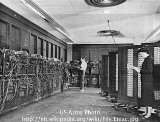

- First general purpose electronic computer
- Programmable, but could not store programs

### Where have we come from - Early Client-Server Computing (1960s)

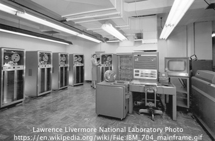

[figure not shown]

[figure not shown]

- Mainframe computers to which client terminals connected over a local network
- Computing performed by server, client purely a display device

### Where have we come from - Personal Computers (1970s)

[figure not shown]

[figure not shown]

- Desktop computers capable of running a variety of operating systems and applications
- In some environments can be interconnected to a central local server

### Now - Network computing

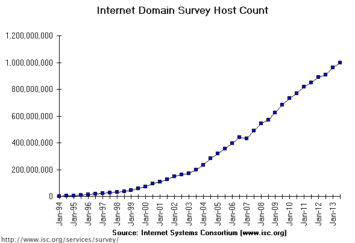

- Predecessor to the Internet - ARPANET (1969). Interconnection between UCLA and SRI (Menlo Park)
- Adoption of TCP/IP as next generation protocol for ARPANET (1983)
- NSF commissions construction of NSFNET, also based upon TCP/IP (1983)
- NSFNET opened to commercial connections (1988). Led to interconnection of multiple, previously separate networks into an “Internet”
- Growth of internet users has expanded rapidly over the past decade

### In a Phrase ...

The current networking computing model consists of *Components Interacting* with Each Other

### So - We Need to Answer the Following Questions

What are components?

What does it mean to interact?

### The Big Picture - Services Oriented Architectures

[figure not shown]

- Services Oriented Architecture (SOA) for Geospatial Data and Processing
  - Data, Processing & Client Tiers
- Open Geospatial Consortium Interoperability Standards
  - WMS, WFS, WCS
- Geospatial Metadata Standards
  - ISO 19115, FGDC
- Internet Standards
  - Web: HTML, CSS, JavaScript, XML
  - SOAP - Simple Object Access Protocol
  - REST - Representation State Transformation

## The Pieces - Components

### Key Components - Data

Database systems

- Optimized for storing massive quantities of tabular data
- May be spatially enabled to support the storage of geometries (points, lines, polygons) in addition to related attribute data
- Standard language (Structured Query Language [SQL]) for interacting with many databases
- Broad support for accessing the contents of databases from many other applications and programming languages, for example:
  - Spreadsheets
  - Statistical Software
  - Geographic Information Systems (GIS)

### Key Components - Data

File-based data

- Often stored on the file system
- Sometimes difficult represent data within a database structure (i.e. binary data)
- May be in a wide variety of formats
  - XML
  - ASCII Text (e.g. CSV, tab-delimited)
  - Binary files
  - Excel Spreadsheets
  - Word Processing Documents
  - Geospatial data (e.g. imagery)
- Remotely Accessible Data
  - Some data may be provided through reference to an external network resource (i.e. a web address, or other identifier) or service

### Key Components - Processing Services

- Perform modification of source data to generate a new data product
- May be “chained” together to create a processing “workflow”. Output from one processing service may be used as the input to another
- May be simple OGC services; or complex data processing, analysis, or visualization services. Examples include
  - Extraction of a subset of a large data set based upon provided search criteria
  - Generation of a map from a collection of data
  - Fusion of two data products into a single derived product (e.g. vegetation indices calculated from multiple remote sensing images)
  - Calculation of statistical information for an input product, and delivery of the statistical summary

### Key Components - Clients

- Any system that accesses the services provided by the system may be considered a “client”
- That system may be manually operated by a human user, or triggered automatically by software
- Human operated clients include
  - Web-based applications
  - Desktop applications such as Geographic Information Systems and Statistical Analysis tools
- Machine clients include
  - Data processing services that translate requests to them into requests for other system services
  - Regularly scheduled requests that are automatically triggered by external computer systems.

## The Glue - Interoperability Standards / Service Interfaces

## Open Geospatial Consortium Interoperability Standards

### Open Geospatial Consortium (OGC) Standards

- Two Classes of Standards Considered Here
  - Geospatial Product Access Standards
  - Geospatial Data and Representation Standards
- Product Access Standards
  - Web Map Services (WMS)
  - Web Feature Services (WFS)
  - Web Coverage Services (WCS)
- Data and Representation Standards
  - Geography Markup Language (GML)
  - KML (formerly known as Keyhole Markup Language)

### Comparison of OGC Service Models

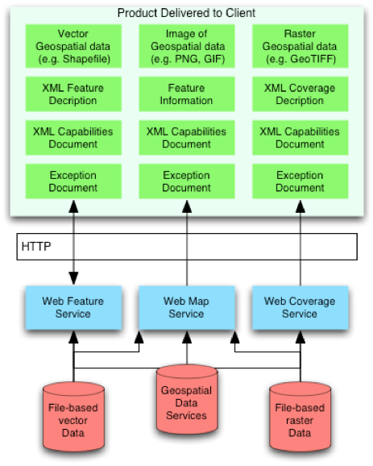

### OGC Web Map Services (WMS)

```
http://gstore.unm.edu/apps/rgis/datasets/b030ab7b-86e3-4c30-91c0-f427303d5c77/services/ogc/wms?
    VERSION=1.1.1&&
    SERVICE=WMS&
    REQUEST=GetMap&
    SRS=EPSG:4326&
    FORMAT=image/jpeg&
    STYLES=&
    LAYERS=bernalillo_tm2011&
    TRANSPARENT=TRUE&
    WIDTH=521&
    HEIGHT=200&
    bbox=-107.207,34.8404,-106.143,35.2487
```

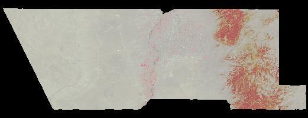

- HTTP GET (required), HTTP POST (optional)
- Requests:
  - `GetCapabilities`
  - `GetMap`
  - `GetFeatureInfo`
- Returns
  - Mapped data
  - XML Capabilities Document, Feature Attributes
- Includes support for time-based requests

### OGC Web Feature Services (WFS)

- Either HTTP GET or POST required
- Requests
  - `GetCapabilities`
  - `DescribeFeatureType`
  - `GetFeature/GetFeatureWithLock`
  - `GetGmlObject`
  - `LockFeature`
  - `Transaction`
- Returns
  - XML (GML)
  - Capabilities
  - Feature Data

### OGC Web Coverage Services (WCS)

- Either HTTP GET or POST required
- Requests
  - `GetCapabilities`
  - `DescribeCoverage`
  - `GetCoverage`
- Returns
  - Geospatial data for coverage
  - XML Capabilities
- Includes support for time-based requests

### OGC Geography Markup Language (GML)

- GML is an XML grammar for representing geospatial features and their associated attributes
- In its generic form it can encode points, lines, and polygons and their associated attributes
- As an XML schema GML was designed to be extensible by communities of practice for consistent encoding of geographic data more richly than allowed by the generic default model
- GML documents representing large complex geometries can be quite large - therefore slow to transfer over the Internet

### OGC KML

- An XML specification that supports the encoding of representation and embedding of geospatial data for use in geospatial viewers
- Began as the underlying representation language of Google Earth (originally developed by Keyhole for their virtual Earth viewer)
- Adopted as an OGC standard in 2008
- Supports data linkage through
  - Embedding
  - Reference through external URLs - with WMS specifically supported through *parameterization*
- Includes support for the representation of time in relation to data objects

### Implementation of the OGC Standards

- WMS
  - 1.3.0 - 284 implementations
  - 1.1.1 - 474
  - 1.1 - 238
  - 1.0 - 274
- WFS
  - 2.0 - 36
  - 2.0 transactional - 3
  - 1.1.0 - 228
  - 1.1.0 transactional - 52
  - 1.0.0 - 304
  - 1.0.0 transactional - 113
- WCS
  - 2.0 - 7
  - 1.1.2 - 19
  - 1.1.1 - 37
  - 1.1.0 - 30
  - 1.0.0 Corregendum - 190

Implementation information based upon [OGC Implementation Statistics](http://www.opengeospatial.org/resource/products/stats) - Accessed 2/2014

### Implementation of the OGC Standards

- KML
  - 2.2.0 - 74
  - 2.2 Reference (Best Practice) - 11
  - 2.1 Reference (Best Practice) - 64
- GML
  - 3.3 - 5
  - 3.2.1 - 110
  - 3.1.1 - 161
  - 3.0 - 127
  - 2.1.2 - 142
  - 2.1.1 - 100
  - 2.0 - 82
  - 1.0 - 20

Implementation information based upon [OGC Implementation Statistics](http://www.opengeospatial.org/resource/products/stats) - Accessed 2/2014

### OGC Summary

The OGC web service specifications support key geospatial data access requirements

**WMS**

visualization of geospatial data through simple web requests

**WFS**

delivery of geospatial data (typically points, lines, and polygons) in a format that is usable in GIS and other applications

**WCS**

delivery of geospatial data (typically, but not limited to, raster data) usable in other applications

### OGC Summary

The OGC data and representation standards support data exchange and higher level representation

**GML**

XML schema for the representation of features and associated attributes. It may be extended for use by specific communities of users (i.e. ecological data models)

**KML**

XML schema that supports the combination of embedded data and external data into a complete representation model that may be used by client applications to present the data through a user interface (e.g. Google Earth, WorldWind)